# 06_3_A_ESmoothing_Trended_Seasonal

```r
library(fpp3)
```

# References

1. Hyndman, R.J., & Athanasopoulos, G. (2021). *Forecasting: principles and practice* (3rd ed.). https://otexts.com/fpp3/
2. Fable package documentation. Retrieved from:
   - https://fable.tidyverts.org/index.html and
   - https://fable.tidyverts.org/articles/fable.html
3. Hyndman, R. J., Koehler, A. B., Ord, J. K., & Snyder, R. D. (2008). *Forecasting with exponential smoothing: The state space approach*. Springer-Verlag.

# Note

This notebook is not original material, but rather based on ref. 1 with notes expanding on some of the concepts contained in the book.

# **Motivation**

Extension of Holt’s Method to capture seasonality. It comprises the **forecast equation** and **three smoothing equations** for the following paramentrs

- The **level** $l_t$ (parameter $\alpha$)
- The **trend** $b_t$ (parameter $\beta*$)
- The **seasonal component** $s_t$ (parameter $\gamma$)

The symbol $m$ is the **length of the seasonality period**, i.e., the duration of seasons a seasonal period. For quarterly data $m = 4$, for monthly data $m= 12$, etc… etc…

# Additive vs Multiplicative

There are two variations of the method.

## Additive

- The **additive** method is preferred when the seasonal variations **do not change proportionally to the level of the series.**
  - **Seasonal component** expressed in **absolute terms** in the **scale of the observed series**
  - Level equation: the series is **seasonally adjusted** by **subtracting the seasonal component**
  - Within a year the seasonal component will add up to approximately zero. See the session *classical decomposition from scratch* to understand why this is:

$$\begin{align*}
\text{For additive seasonal ETS:} && \sum_{i=1}^{m} s_i \approx 0
\end{align*}$$
As a result, the seasonal component does not contribute to the average of the time series over one period.

## Multiplicative

- The **multiplicative method** is preferred when the **seasonal variations change proportionally to the level of the series**.
  - **Seasonal component** expressed in relative terms (percentages)
  - Level equation: the series is **seasonally adjusted** by **dividing through by the seasonal component**.
  - Within a year the **seasonal component will sum up to approximately $m$.**. See the session *classical decomposition from scratch* to understand the reason.

$$\begin{align*}
\text{For multiplicative seasonal ETS:} && \sum_{i=1}^{m} s_i \approx m
\end{align*}$$

# Holt’s Winters’ additive method

## Component form of the equations

Unlike for Simple Exponential Smoothing, we will not derive the equations. We will accept them and then interpret them further down below. For those interested, see reference 3.

**Differences with trended exponential smoothing**:

- Introduce new parameter, the **seasonal index $s_t$**.
  - This implies introducing a **new equation for the seasonal index**.
- The **seasonal index has its own smoothing parameter $\gamma$**.

**Component form equations**:

$$\begin{align*}
\text{Forecast equation}&& \hat{y}_{t+h|t} &= \ell_{t} + hb_{t} + s_{t+h-m(k+1)} \\
\text{Level equation}&& \ell_{t} &= \alpha(y_{t} - s_{t-m}) + (1 - \alpha)(\ell_{t-1} + b_{t-1})\\
\text{Trend equation}&& b_{t} &= \beta^*(\ell_{t} - \ell_{t-1}) + (1 - \beta^*)b_{t-1}\\
\text{Seasonal equation}&& s_{t} &= \gamma (y_{t}-\ell_{t-1}-b_{t-1}) + (1-\gamma)s_{t-m},
\end{align*}$$

## $k$ subindex in the seasonal component

The subindex $k = int(\frac{h-1}{m})$ might be confusing.

- $int()$ is the function *integer part*. This function returns the integer part of any given real number. for example:
  - int(0.1) = 0
  - int(1.182341) = 1
  - int(2.154) = 2
  - …
- $h$ is the forecast horizon.
- $m$ is the length of the seasonal period. Some examples:
  - For quarterly data and a seasonal period of 1 year: $m=4$
  - For monthly data and a seasonal period of 1 year: $m=12$
  - For daily data and a seasonal period of 1 week: $m=7$
  - For weekly data and a seasonal period of 1 year: $m=52$
  - …

The figure below helps understand what the expression $k = int(\frac{h-1}{m})$ attains. $k$ is the **number of seasonal periods between the current forecast horizon and the latest observed season**. To simplify notation for the reader, the figure has been drawn considering a specific example with $m=12$ (monthly data and a yearly seasonal period):

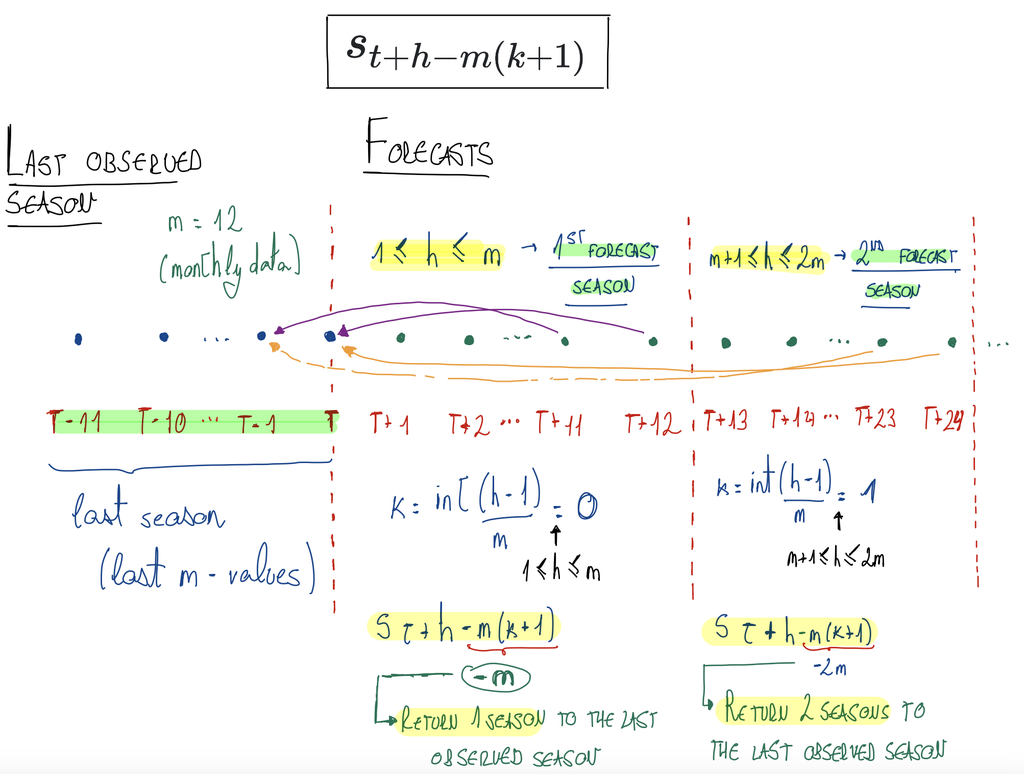

## Equations for the fitted values

To understand how these equations help fit a model to a time series with both trend and seasonality, let us particularize the forecast equation for $h=1$ (fitted values are one-step ahead forecasts on the training data). We will subsequently particularize the equation at time $t$ instead of the resulting $t+1$, to make it consistent with the level and trend equations.

- **NOTE** for $h=1$ we have $k=int(\frac{h-1}{m}) = 0$. This is also considered in the equation below

$$\begin{align*}
\text{Forecast equation for h = 1} && \hat{y}_{t+1|t} &= \ell_{t} + 1\cdot b_{t} + s_{t+1-m} \\
\text{Particularize for t instead t+1} && \hat{y}_{t|t-1} &= \ell_{t-1} + 1\cdot b_{t-1} + s_{t-m} && (\text{fitted value at t})\\
\end{align*}$$

Therefore, the **equations for the fitted values are:**

$$\begin{align*}
\text{Fitted value at t} && \hat{y}_{t|t-1} &= \ell_{t-1} + b_{t-1} + s_{t-m} \\
\text{Level equation}&& \ell_{t} &= \alpha(y_{t} - s_{t-m}) + (1 - \alpha)(\ell_{t-1} + b_{t-1})\\
\text{Trend equation}&& b_{t} &= \beta^*(\ell_{t} - \ell_{t-1}) + (1 - \beta^*)b_{t-1}\\
\text{Seasonal equation}&& s_{t} &= \gamma (y_{t}-\ell_{t-1}-b_{t-1}) + (1-\gamma)s_{t-m},
\end{align*}$$

**These equations allow us to determine the fitted values if given**:

1. The values of the smoothing parameters $\alpha$, $\beta^*$ and $\gamma$
2. An initial value for the level $l_{0}$
3. An initial value for the trend $b_{0}$
4. Initial values for the **seasonal indices of an entire initial season:** $(s_0, s_{-1}, s_{-2}, \dots, s_{1-m})$
   - Note that the previous vector consists of $m$ seasonal indices, given as initial values.
   - The excel file in which you will do an example for quarterly data should help clarify this.

The **process to compute the fitted values having this data is as follows:**

- For $t = 1$:
  1. $\hat{y}_{1|0} = \ell_{0} + b_{0} + s_{1+1-m}$
  2. $l_{1} = \alpha(y_{1}-s_{1-m}) + (1 - \alpha)(l_{0} + b_{0})$
     - The value of $l_1$ will be used in the trend equation next.
  3. $b_{1} = \beta^*(l_{1} - l_{0}) + (1 -\beta^*)b_{0}$
  4. $s_1 = \gamma(y_t-l_{0}-b_{0})+(1-\gamma)s_{1-m}$
- For $t = 2$: we proceed in the same manner after having computed $l_1$ and $b_1$ and $s_1$ in the previous step.
- For $t = 3$: we proceed in the same manner after having computed $l_2$ and $b_2$ and $s_2$ in the previous step.
- …

### Interpreting the equations

Let us briefly interpret the equations:

#### Level equation

Weighted average between the seasonally adjusted observation and the non-seasonal forecast

$$\begin{align*}
l_{t} &= \alpha\underbrace{(y_{t} - s_{t-m})}_{\substack{\textrm{seasonally adjusted} \\ \textrm{observation}}} + (1 - \alpha)\underbrace{(\ell_{t-1} + b_{t-1})}_\textrm{non seasonal forecast}\\
\end{align*}$$

#### Trend equation

identical to Holt’s linear additive method. See the previous session.

$$\begin{align*}
\text{Trend equation} && b_{t} &= \beta^*\underbrace{(\ell_{t} - \ell_{t-1})}_{\substack{\textrm{estimated trend} \\ \textrm{at time t}}} + (1 -\beta^*)\underbrace{b_{t-1}}_{\substack{\textrm{previous} \\ \textrm{estimate} \\ \textrm{of the trend}}},
\end{align*}$$

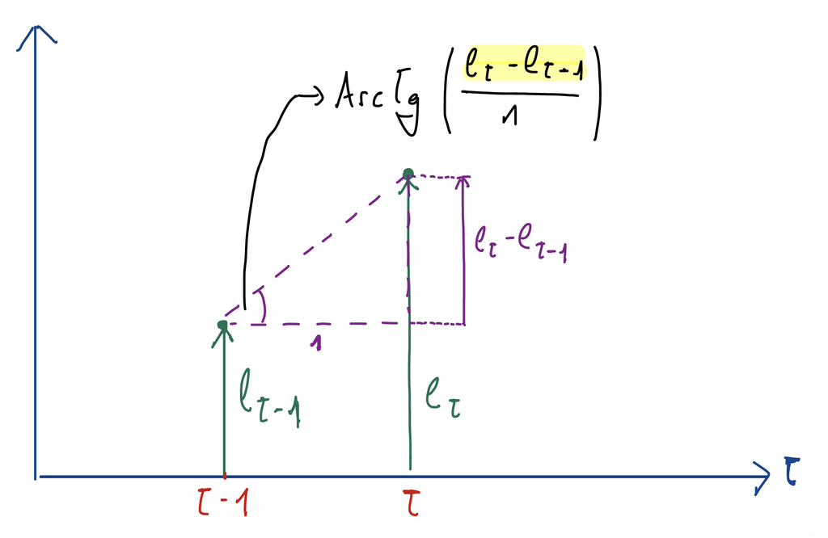

#### The seasonal equation

weighted average between an estimate of the current seasonal index and the seasonal index of the same observation for in the previous season ($m$ periods ago).

$$\begin{align*}
s_{t} &= \gamma \underbrace{(y_{t}-\ell_{t-1}-b_{t-1})}_{\substack{\textrm{estimate of} \\ \textrm{current seasonal index}}} + (1-\gamma)\underbrace{s_{t-m}}_{\substack{\textrm{seasonal index} \\ \textrm{of the} \\ \textrm{same season} \\ \textrm{last year}}}
\end{align*}$$

- **NOTE:** $y_{t}-\ell_{t-1}-b_{t-1}$ is an estimate the current seasonal index because we remove from the observation at time t the effect of the level and the slope at the previous step. This results in an estimate of the current seasonal index.

#### Fitted value equation

The fitted value at $t$ is obtained just as in Holt’s method, only now the seasonal index of the matching observation in the previous session ($s_{t-m}$) is added.

$$\begin{align*}
\text{Fitted value at t} && \hat{y}_{t|t-1} &= \ell_{t-1} + 1 \cdot b_{t-1} + s_{t-m} \\
\end{align*}$$

## Equation for the forecasts

Once the fitted values $\hat{y_t}$, the levels $l_t$, the slopes $b_t$ and the seasonal indices $s_t$ have been computed for every value of in the training region (from to $t=1$ to $t=T$) we can compute the forecasts.

That is, once we have fitted the model the forecasts beyond the training region are given by:

$$\begin{align*}
\text{Forecast equation} && \hat{y}_{T+h|T} &= \ell_{T} + hb_{T} + s_{T+h-m(k+1)}
\end{align*}$$

- where $t=T$ is **the last point in time of the training data**.
- $k = int(\frac{h-1}{m})$. See the previous sections for the interpretation of $k$.

Note that **only the last values $l_T$, $b_T$ and the last season of the seasonal indices $s_{T+h-m(k+1)$** intervene in the forecasts.

You can see that **the h-step ahead forecast is equal to the last estimated level plus h times the last estimated trend value plus the value of the seasonal index corresponding to the last estimated season**

# Holt Winter’s multiplicative Method

In the multiplicative variant of Holt-Winter’s method:

1. The level $l_t$ and the trend $b_t$ relate in an **additive manner**.
2. The seasonal index $s_{t+h-m(k+1)}$ relates in a multiplicative manner with them both.

The resulting equations are equivalent to those of the additive method, but **now the seasonal indices multiply if they were adding before and divide if the were being subtracted**. This results in:

$$\begin{align*}
\hat{y}_{t+h|t} &= (\ell_{t} + hb_{t})s_{t+h-m(k+1)} \\
\ell_{t} &= \alpha \frac{y_{t}}{s_{t-m}} + (1 - \alpha)(\ell_{t-1} + b_{t-1})\\
b_{t} &= \beta^*(\ell_{t}-\ell_{t-1}) + (1 - \beta^*)b_{t-1} \\
s_{t} &= \gamma \frac{y_{t}}{(\ell_{t-1} + b_{t-1})} + (1 - \gamma)s_{t-m}.
\end{align*}$$

The equation for the fitted values is obtained just as for the additive method:

1. Particularize the forecast equation for $h=1$.
2. Particularize the result at $t$ instead of $t+1$

This will not be done in this notebook. Feel free to do it as an exercise and try to reproduce the table for the fitted values corresponding to the multiplicative case in the next section to ensure you have done it correctly.

# Fitting the models

Fitting the Holt-Winter’s method to a time series implies the following process to minimize the Sum of Squared Residuals (SSE). In this case, we are not going to implement this from scratch as we did for simple exponential smoothing. An understanding of the process is sufficient.

**Importantly**, we **now require initial values for an entire season for the seasonal indices**. This **increases a lot the number of parameters involved**.

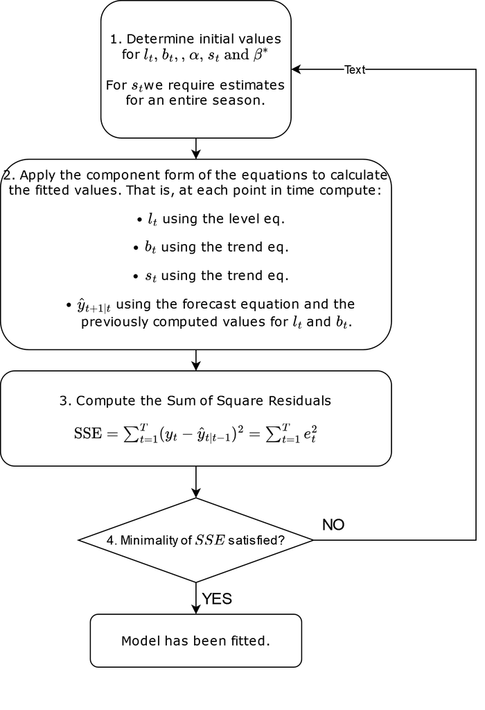

## Example for the additive case

In the table below, an example for the fitted values for **Holt-Winters’ method with additive seasonality** is computed. For that, the following initial values are required:

- The level $l_t$ of the series - estimated as the average of the observations in the first period (first four observations)
- The slope of the series $b_t$ - since the series send to have no trend within the first season, we estimate it as 0.
- Since in this case $m=4$, we require initial estimates of the first 4 seasonal components.
  - **NOTE:** a possible way to produce this estimates is as the first four elements of the seasonal component of a classical decomposition (additive) of the series.
  - **NOTE** that for monthly data we would require 12 estimates. With longer seasonal periods this becomes increasingly complex.

| Quarter | Time | Observation | Level | Slope | Season | Forecast |
| --- | --- | --- | --- | --- | --- | --- |
|  | t | $y_t$ | $l_t$ | $b_t$ | $s_t$ | $\hat{y}_{t+1\|t}$ |
| 1997 Q1 | 0 |  |  |  | 1.5 |  |
| 1997 Q2 | 1 |  |  |  | -0.3 |  |
| 1997 Q3 | 2 |  |  |  | -0.7 |  |
| 1997 Q4 | 3 |  | 9.8 | 0.0 | -0.5 |  |
| 1998 Q1 | 4 | 11.8 | 9.9 | 0.0 | 1.5 | 11.3 |
| 1998 Q2 | 5 | 9.3 | 9.9 | 0.0 | -0.3 | 9.7 |
| 1998 Q3 | 6 | 8.6 | 9.7 | -0.0 | -0.7 | 9.2 |
| 1998 Q4 | 7 | 9.3 | 9.8 | 0.0 | -0.5 | 9.2 |
|  | … | … | … | … | … | … |
| 2017 Q1 | 80 | 12.4 | 10.9 | 0.1 | 1.5 | 12.3 |
| 2017 Q2 | 81 | 10.5 | 10.9 | 0.1 | -0.3 | 10.7 |
| 2017 Q3 | 82 | 10.5 | 11.0 | 0.1 | -0.7 | 10.3 |
| 2017 Q4 | 83 | 11.2 | 11.3 | 0.1 | -0.5 | 10.6 |
|  | $h$ |  |  |  |  | $\hat{y}_{T+h}$ |
| 2018 Q1 | 1 |  |  |  |  | 12.9 |
| 2018 Q2 | 2 |  |  |  |  | 11.2 |
| 2018 Q3 | 3 |  |  |  |  | 11.0 |
| 2018 Q4 | 4 |  |  |  |  | 11.2 |
| 2019 Q1 | 5 |  |  |  |  | 13.4 |
| 2019 Q2 | 6 |  |  |  |  | 11.7 |
| 2019 Q3 | 7 |  |  |  |  | 11.5 |
| 2019 Q4 | 8 |  |  |  |  | 11.7 |
| 2020 Q1 | 9 |  |  |  |  | 13.9 |
| 2020 Q2 | 10 |  |  |  |  | 12.2 |
| 2020 Q3 | 11 |  |  |  |  | 11.9 |
| 2020 Q4 | 12 |  |  |  |  | 12.2 |

## Example for multiplicative case

In the table below, an example for the fitted values for **Holt-Winters’ method with multiplicative seasonality** is computed. For that, the following initial values are required:

The following table does the same but following a multiplicative approach:

- The level $l_t$ of the series - estimated as the average of the observations in the first period (first four observations)
- The slope of the series $b_t$ - since the series send to have no trend within the first season, we estimate it as 0.
- Since in this case $m=4$, we require initial estimates of the first 4 seasonal components.
  - **NOTE:** a possible way to produce this estimates is as the first four elements of the seasonal component of a classical decomposition (multiplicative) of the series.
  - **NOTE** that for monthly data we would require 12 estimates. With longer seasonal periods this becomes increasingly complex.

| Quarter | Time | Observation | Level | Slope | Season | Forecast |
| --- | --- | --- | --- | --- | --- | --- |
|  | $t$ | $y_t$ | $l_t%$ | $b_t$ | $s_t$ | $y_{t+1}$ |
| 1997 Q1 | 0 |  |  |  | 1.2 |  |
| 1997 Q2 | 1 |  |  |  | 1.0 |  |
| 1997 Q3 | 2 |  |  |  | 0.9 |  |
| 1997 Q4 | 3 |  | 10.0 | -0.0 | 0.9 |  |
| 1998 Q1 | 4 | 11.8 | 10.0 | -0.0 | 1.2 | 11.6 |
| 1998 Q2 | 5 | 9.3 | 9.9 | -0.0 | 1.0 | 9.7 |
| 1998 Q3 | 6 | 8.6 | 9.8 | -0.0 | 0.9 | 9.2 |
| 1998 Q4 | 7 | 9.3 | 9.8 | -0.0 | 0.9 | 9.2 |
|  | … | … | … | … | … | … |
| 2017 Q1 | 80 | 12.4 | 10.8 | 0.1 | 1.2 | 12.6 |
| 2017 Q2 | 81 | 10.5 | 10.9 | 0.1 | 1.0 | 10.6 |
| 2017 Q3 | 82 | 10.5 | 11.1 | 0.1 | 0.9 | 10.2 |
| 2017 Q4 | 83 | 11.2 | 11.3 | 0.1 | 0.9 | 10.5 |
|  | $h$ |  |  |  |  | $\hat{y}_{T+h\vert T}$ |
| 2018 Q1 | 1 |  |  |  |  | 13.3 |
| 2018 Q2 | 2 |  |  |  |  | 11.2 |
| 2018 Q3 | 3 |  |  |  |  | 10.8 |
| 2018 Q4 | 4 |  |  |  |  | 11.1 |
| 2019 Q1 | 5 |  |  |  |  | 13.8 |
| 2019 Q2 | 6 |  |  |  |  | 11.7 |
| 2019 Q3 | 7 |  |  |  |  | 11.3 |
| 2019 Q4 | 8 |  |  |  |  | 11.6 |
| 2020 Q1 | 9 |  |  |  |  | 14.4 |
| 2020 Q2 | 10 |  |  |  |  | 12.2 |
| 2020 Q3 | 11 |  |  |  |  | 11.7 |
| 2020 Q4 | 12 |  |  |  |  | 12.1 |

## Exercise: reproduce these tables (excels provided by professor)

# R Example: Domestic overnight trips in Australia

## Model specification to fit a Holt-Winters model with additive seasonality:

In the ETS() formula:

- Specify `error("A")` (additive errors)
- Specify `trend("A")`
- Specify `season("A")`

`ETS(VARIABLE ~ error("A") + trend("A") + season("A"))`

## Model specification to fit a Holt-Winters model with multiplicative seasonality:

In the ETS() formula:

- Specify `error("M")` (multiplicative errors)
- Specify `trend("A")`
- Specify `season("M")`

`ETS(VARIABLE ~ error("M") + trend("A") + season("M"))`

**IMPORTANT NOTE**: it is **very important** that if you specify **`season("M")`**, you also specify **`error("M")`**. Otherwise your model could face numerical instabilities and your computer could either never finish fitting the model or fail to fit the model.

## Code

Let us consider the number of total trips to Australia for the purpose “Holiday”. We will fit both a Holt-Winter’s additive and a Holt-Winter’s multiplicative method to this data.

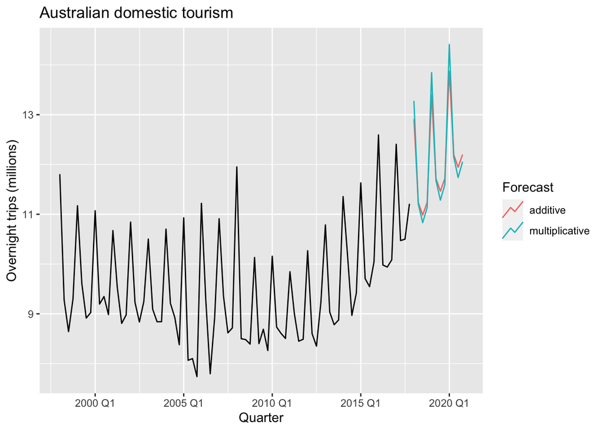

```r
# Filter data
aus_holidays <- tourism %>%
  filter(Purpose == "Holiday") %>%
  summarise(Trips = sum(Trips)/1e3)

# Fit the models: additive and multiplicative seasonality
# Pay attention to the error terms! (for numerical stability):
  # error("A") for the additive model.
  # error("M") for the multiplicative model.
fit <- aus_holidays %>%
  model(
    additive = ETS(Trips ~ error("A") + trend("A") + season("A")),
    multiplicative = ETS(Trips ~ error("M") + trend("A") + season("M"))
  )

# Generate forecasts
fc <- fit %>% forecast(h = "3 years")

# Plot the forecasts
fc %>%
  autoplot(aus_holidays, level = NULL) +
  labs(title="Australian domestic tourism",
       y="Overnight trips (millions)") +
  guides(colour = guide_legend(title = "Forecast"))
```

Comparing the fit accuracy metrics, we see that the multiplicative model has a slightly smaller residuals RMSE (better fit). The difference, however, is not substantial.

- **NOTE**: RMSE will be explained in the session on point forecasts.

```r
fit %>% accuracy() %>% select(.model, RMSE) %>% mutate(RMSE = round(RMSE, 4))
```

```
# A tibble: 2 × 2
  .model          RMSE
  <chr>          <dbl>
1 additive       0.417
2 multiplicative 0.412
```

We can plot the components of the resulting ETS decomposition (fitted values)

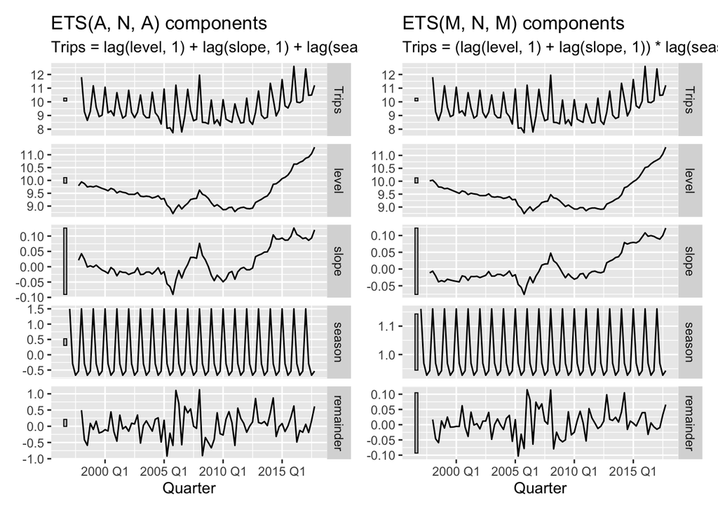

```r
fig_additive <- fit %>%
  select("additive") %>%
  components() %>%
  autoplot() +
  labs(title = "ETS(A, N, A) components")

fig_multiplicative <- fit %>%
  select("multiplicative") %>%
  components() %>%
  autoplot() +
  labs(title = "ETS(M, N, M) components")

# Used patchwork library syntax to organize plots
fig_additive + fig_multiplicative
```

These models already have a substantial number of parameters! This is because the models require a lot of initial estimates, that in the end are also a parameter. Let us examine them using `tidy()`

```r
fit %>% tidy()
```

```
# A tibble: 18 × 3
   .model         term   estimate
   <chr>          <chr>     <dbl>
 1 additive       alpha  0.262
 2 additive       beta   0.0431
 3 additive       gamma  0.000100
 4 additive       l[0]   9.79
 5 additive       b[0]   0.0211
 6 additive       s[0]  -0.534
 7 additive       s[-1] -0.670
 8 additive       s[-2] -0.294
 9 additive       s[-3]  1.50
10 multiplicative alpha  0.224
11 multiplicative beta   0.0304
12 multiplicative gamma  0.000100
13 multiplicative l[0]  10.0
14 multiplicative b[0]  -0.0114
15 multiplicative s[0]   0.943
16 multiplicative s[-1]  0.927
17 multiplicative s[-2]  0.969
18 multiplicative s[-3]  1.16
```

- The small value of $\gamma$ for both models means that the seasonal component barely changes over time.
- The small value of $\beta*$ means that the slope component barely changes over time.
- 3 smoothing parameters $\alpha$, $\beta*$ and $\gamma$.
- 6 initial estimates!! (1 for the level $l_0$, one for the trend $b_0$ and 4 for the seasonal comonent $s_{-3}, s_{-2}, ..., s_{0}$. **If the data were monthly we would require 12 estimates**. For longer seasonal periods (e.g. weekly data and yearly seasonality) the problem becomes substantially complex!

Recall the famous quote by the great mathematician John von Neumann:

*“With four parameters I can fit an elephant and with five I can make it wiggle his trunk”* (John von Neuman, cited by Enrico Fermi in Nature 427).

# Holt-Winters damped method

This is often the single most accurate method for seasonal data. The difference is that now we include a damped trend in the multiplicative method, in the same mannera as we did for additive models.

$$\begin{align*}
\hat{y}_{t+h|t} &= \left[\ell_{t} + (\phi+\phi^2 + \dots + \phi^{h})b_{t}\right]s_{t+h-m(k+1)} \\
\ell_{t} &= \alpha(y_{t} / s_{t-m}) + (1 - \alpha)(\ell_{t-1} + \phi b_{t-1})\\
b_{t} &= \beta^*(\ell_{t} - \ell_{t-1}) + (1 - \beta^*)\phi b_{t-1} \\
s_{t} &= \gamma \frac{y_{t}}{(\ell_{t-1} + \phi b_{t-1})} + (1 - \gamma)s_{t-m}.
\end{align*}$$

## Model specification to fit a Holt-Winters damped model:

Holt-Winters’ method can be damped in both its additive and multiplicative forms. With multiplicative seasonality it is often a very good model that is computationally simpler than many other models that fail to outperform it.

In the ETS() formula:

- Specify `error("M")`
- Specify `trend("Ad")`
- Specify `season("M")`

`ETS(VARIABLE ~ error("M") + trend("Ad") + season("M"))`

## R Example with daily data

- m = 7 (seasonal period, 1 week)

```r
sth_cross_ped <- pedestrian %>%
  filter(Date >= "2016-07-01",
         Sensor == "Southern Cross Station") %>%
  index_by(Date) %>%
  summarise(Count = sum(Count)/1000)

sth_cross_ped
```

```
# A tsibble: 184 x 2 [1D]
   Date       Count
   <date>     <dbl>
 1 2016-07-01 17.6
 2 2016-07-02  2.52
 3 2016-07-03  1.73
 4 2016-07-04 17.3
 5 2016-07-05 16.5
 6 2016-07-06 16.8
 7 2016-07-07 17.0
 8 2016-07-08 17.2
 9 2016-07-09  3.21
10 2016-07-10  1.75
# ℹ 174 more rows
```

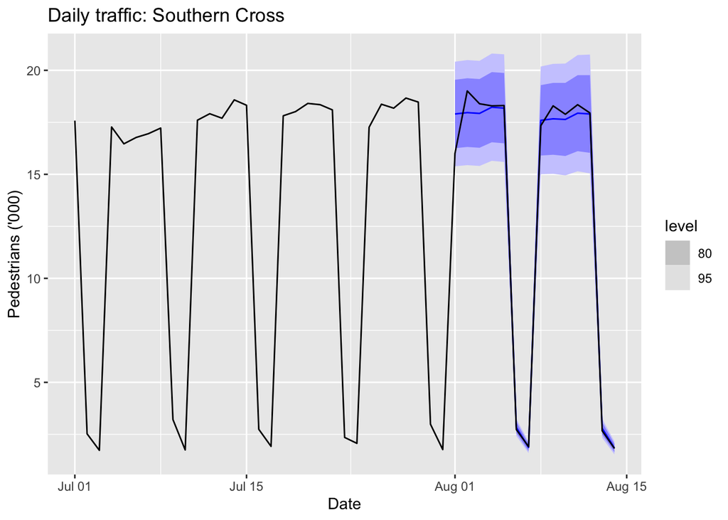

```r
fit <- sth_cross_ped %>%
  filter(Date <= "2016-07-31") %>%
  model(
    hw = ETS(Count ~ error("M") + trend("Ad") + season("M"))
  )

fc <- fit %>%
  forecast(h = "2 weeks")

fc %>%
  autoplot(sth_cross_ped %>% filter(Date <= "2016-08-14")) +
  labs(title = "Daily traffic: Southern Cross",
       y="Pedestrians ('000)")
```

The model has identified the weekly seasonal pattern and the increasing trend at the end of the data.

The forecasts are a close match to the test data.

# Exercise Seasonal Exp Smoothing

For this exercise use the quarterly number of arrivals to Australia from New Zealand, 1981 Q1 – 2012 Q3, from data set `aus_arrivals`.

```
Plot variable not specified, automatically selected `.vars = Arrivals`
```

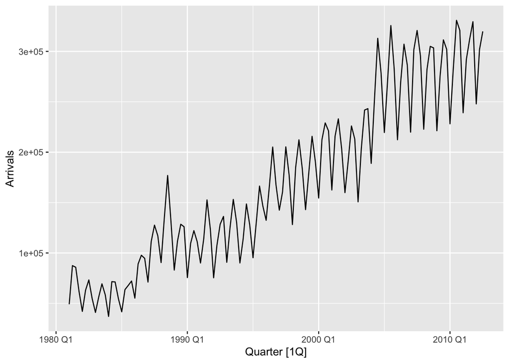

```r
nz_arrivals <- aus_arrivals %>% filter(Origin == "NZ")
nz_arrivals %>% autoplot()
```

## 1. Timeplot

Make a time plot of your data adjusting the grid to properly identify a yearly seasonality.

Would you say that multiplicative seasonality is necessary?

## 2. Fit models to a training dataset

The code below creates a sub-slice of `nz_arrivals` that leaves out the last 8 observations. That is, it creates a **training dataset** `nz_tr`

```r
nz_tr <- nz_arrivals %>%
  slice(1:(n() - 8))
```

Fit the following models to `nz_tr`:

1. A Holt-Winter’s model with additive seasonality. Call it `hw_additive`
2. A Holt-Winter’s model with mutliplicative seasonality. Call it `hw_multipicative`
3. A Holt-Winter’s model with a damped trend and multiplicative seasonality. Call it `hw_multipicative_damped`

## 3. Forecast 8 steps ahead

## 4. Graphs for the forecasts

Create the following graphs

1. Forecasts along historical time series of all the models together without confidence intervals.
2. Forecasts along historical time series for holt-winters multiplicative method with damped trend, including confidence intervals.
3. Forecasts along historical time series for holt-winters additive method.
4. Forecasts along historical time series for holt-winters multiplicative seasonality and damped trend:
5. Do you reach any conclusion?

## Questions on point-forecast accuracy and cross-validation.

Use cross-validation to compare the performance of the models below with forecasts up to 10 steps ahead:

- a Seasonal Naïve method, which we will use as benchmark. Call it `snaive`
- an ETS model fitted to the data without transformation. It must include an additive trend and appropriate seasonality. Call this model `ETS_original`.
- an ETS model fitted to the data without transformation. It must include an additive damped trend and appropriate seasonality. Call this model `ETS_original_Ad`.
- an ETS model fitted to the log-transformed data. It must include an additive trend and appropriate seasonality. Call this model `ETS_original_log`.
- an ETS model fitted to the log-transformed data. It must include an additive damped trend and appropriate seasonality. Call this model `ETS_original_Ad_log`.
- a `decomposition_model()` that applies a default STL decomposition to the data and then uses:
  - a trended ETS for the seasonality adjusted data (only trend and no seasonality).
  - a seasonal ETS model for the seasonal component (only seasonality, no trend).
  - call this model `dcmp_ETS`

Regarding the training datasets, the smallest one must have 80% of the observations in the dataset and must grow in steps of 1 observation.

### 5. Create the training datasets using `stretch_tsibble`:

Apply `stretch_tsibble` to `nz_arrivals`

### 6. Fit the models to the training datasets

### 7.

Perform forecasts of up to 10 steps ahead. Introduce a column `h` that indicates the horizon corresponding to each of the forecasts. Pay attention that, at the end of the process, the resulting object is still a fable (see session on cross-validation to understand how to do this).

### 8.

Compute the cross-validated accuracy metrics for each model, averaged over all forecast horizons.

Provide an interpretation of the MAE of the best model.

### 9.

Compute the cross-validated accuracy metrics for each model and forecast horizon.

Afterwards, create a table that contains only the best model in terms of RMSE for each forecast horizon.

Finally create a figure that shows which model is best for each forecast horizon in terms of RMSE.

### 10.

Take your best model (on average over all horizons), fit it to the data and analyze its residuals.